# Advanced SQL

Mirko MÃ¤licke

```sql
select * from data limit 20
```

| id | date | variable_id | value |
| --- | --- | --- | --- |
| 2814 | 1957-03-10 | 5 | -1.5 |
| 2814 | 1957-03-11 | 5 | -3.3 |
| 2814 | 1957-03-12 | 5 | -3.6 |
| 2814 | 1957-03-13 | 5 | -1.9 |
| 2814 | 1957-03-14 | 5 | 2.3 |
| 2814 | 1957-03-15 | 5 | 4.6 |
| 2814 | 1957-03-16 | 5 | 6.0 |
| 2814 | 1957-03-17 | 5 | 4.9 |
| 2814 | 1957-03-18 | 5 | 7.1 |
| 2814 | 1957-03-19 | 5 | 6.6 |

[output cut: 10 more lines]

Build a temporary table called *name_precipitation*, where you should replace *name* with your actual name. This table shall contain all measurements from the data table holding precipitation information.

```sql
create temporary table elisa_precipitation as
select id, date, value as precipitation from data where variable_id=1
```

```sql
select * from elisa_precipitation limit 20
```

| id | date | precipitation |
| --- | --- | --- |
| 257 | 1949-01-01 | 26.5 |
| 257 | 1949-01-02 | 9.0 |
| 257 | 1949-01-03 | 0.0 |
| 257 | 1949-01-04 | 1.5 |
| 257 | 1949-01-05 | 0.0 |
| 257 | 1949-01-06 | 0.0 |
| 257 | 1949-01-07 | 0.0 |
| 257 | 1949-01-08 | 1.3 |
| 257 | 1949-01-09 | 0.0 |
| 257 | 1949-01-10 | 0.0 |

[output cut: 10 more lines]

Create a view on this table that holds monthly statistics for every station id. Calculate the monthly sum, the highest observed daily rainfall sum, the number of extreme rainfalls (daily precipitation > 30).

```sql
create temporary view elisa_precipitation_month as
select id, date_trunc('month', date) as month,
sum(precipitation) as sum,
max(precipitation) as max,
count(case when precipitation > 30.0 then precipitation end) as n_extreme_pp
from elisa_precipitation group by id, month
```

```sql
select * from elisa_precipitation_month limit 10
```

| id | month | sum | max | n_extreme_pp |
| --- | --- | --- | --- | --- |
| 257 | 1949-01-01 | 77.4 | 26.5 | 0 |
| 257 | 1949-02-01 | 35.3 | 9.3 | 0 |
| 257 | 1949-03-01 | 40.9 | 10.8 | 0 |
| 257 | 1949-04-01 | 71.5 | 12.2 | 0 |
| 257 | 1949-05-01 | 94.4 | 15.3 | 0 |
| 257 | 1949-06-01 | 33.3 | 17.5 | 0 |
| 257 | 1949-07-01 | 10.6 | 5.0 | 0 |
| 257 | 1949-08-01 | 81.6 | 27.1 | 0 |
| 257 | 1949-09-01 | 52.0 | 14.7 | 0 |
| 257 | 1949-10-01 | 60.5 | 27.6 | 0 |

Create a view on the last view, that aggregates the same statistics for anual overviews.

```sql
create temporary view elisa_precipitation_year as
select id, date_trunc('year', month) as year,
sum(sum) as sum,
max(sum) as max,
sum(n_extreme_pp) as extreme_in_year
from elisa_precipitation_month group by id, year
```

```sql
select * from elisa_precipitation_year * limit 10
```

| id | year | sum | max | extreme_in_year |
| --- | --- | --- | --- | --- |
| 257 | 1949-01-01 | 756.6 | 105.8 | 0 |
| 257 | 1950-01-01 | 1239.2 | 202.1 | 2 |
| 257 | 1951-01-01 | 1086.6 | 177.3 | 0 |
| 257 | 1952-01-01 | 1214.4 | 210.5 | 4 |
| 257 | 1953-01-01 | 747.8 | 183.5 | 4 |
| 257 | 1954-01-01 | 1176.1 | 199.3 | 3 |
| 257 | 1955-01-01 | 1110.1 | 185.0 | 8 |
| 257 | 1956-01-01 | 1112.3 | 190.5 | 3 |
| 257 | 1957-01-01 | 1008.5 | 165.2 | 2 |
| 257 | 1958-01-01 | 1348.9 | 271.9 | 5 |

Which station observed the highest monthly rainfall sum?

```sql
select e.id as station, name, sum as max_monthly_rainfall_sum
from elisa_precipitation_month e
join stations s on s.id=e.id
order by sum desc limit 1
```

| station | name | max_monthly_rainfall_sum |
| --- | --- | --- |
| 1468 | Freudenstadt | 635.5 |

Which station observed the most extreme rainfall occurences within one month?

```sql
select e.id as station_with_max_pp_month, name, n_extreme_pp as number_of_extreme_events_within_month
from elisa_precipitation_month e
join stations s on s.id=e.id
order by n_extreme_pp desc limit 1
```

| station_with_max_pp_month | name | number_of_extreme_events_within_month |
| --- | --- | --- |
| 1468 | Freudenstadt | 8 |

Which within one year?

```sql
select e.id as station_with_max_pp_year, name, extreme_in_year as number_of_extreme_events_within_year
from elisa_precipitation_year e
join stations s on s.id=e.id
order by extreme_in_year desc limit 1
```

| station_with_max_pp_year | name | number_of_extreme_events_within_year |
| --- | --- | --- |
| 1468 | Freudenstadt | 21 |

Which was the year with the most overall extreme rainfall occurences? (ignoring the station)

```sql
select year as year_with_max_extreme_events, extreme_in_year as number_of_extreme_events_within_year
from elisa_precipitation_year order by extreme_in_year desc limit 1
```

| year_with_max_extreme_events | number_of_extreme_events_within_year |
| --- | --- |
| 1986-01-01 | 21 |

Which is the station with the most extreme rainfall events within this year (from the last chunk)?

```sql
select date_trunc('year', year), e.id as station, name
from elisa_precipitation_year e
join stations s on s.id=e.id
order by extreme_in_year desc limit 1
```

| date_trunc | station | name |
| --- | --- | --- |
| 1986-01-01 | 1468 | Freudenstadt |

Which one with the most extreme rainfall events overall?

```sql
select e.id as station_with_most_extreme_rainfall_events_id, name
from elisa_precipitation_year e
join stations s on s.id=e.id
order by extreme_in_year desc limit 1
```

[output not shown]

Create a view, that includes only the records from *data* which fulfilled the extreme rainfall constraint.

```sql
create temporary view e_extreme_rain_events as
select id, date, value as precipitation from data where variable_id=1 and value > 30.0;
```

```sql
select * from e_extreme_rain_events limit 50
```

| id | date | precipitation |
| --- | --- | --- |
| 257 | 1950-07-14 | 37.0 |
| 257 | 1950-11-29 | 34.6 |
| 257 | 1952-02-11 | 31.6 |
| 257 | 1952-03-25 | 63.1 |
| 257 | 1952-03-31 | 41.2 |
| 257 | 1952-09-12 | 35.2 |
| 257 | 1953-05-27 | 33.3 |
| 257 | 1953-06-09 | 50.2 |
| 257 | 1953-07-13 | 30.2 |
| 257 | 1953-07-29 | 39.2 |

[output cut: 40 more lines]

Join another column to this view, that holds the *type of precipitation* variable.

```sql
select d.id as id_station, d.date, precipitation, value as type_of_pp from e_extreme_rain_events e
join data d
on d.id=e.id
where d.variable_id=3 and d.date=e.date
limit 100
```

| id_station | date | precipitation | type_of_pp |
| --- | --- | --- | --- |
| 257 | 1950-07-14 | 37.0 | 1 |
| 257 | 1950-11-29 | 34.6 | 1 |
| 257 | 1952-02-11 | 31.6 | 8 |
| 257 | 1952-03-25 | 63.1 | 8 |
| 257 | 1952-03-31 | 41.2 | 8 |
| 257 | 1952-09-12 | 35.2 | 1 |
| 257 | 1953-05-27 | 33.3 | 1 |
| 257 | 1953-06-09 | 50.2 | 1 |
| 257 | 1953-07-13 | 30.2 | 1 |
| 257 | 1953-07-29 | 39.2 | 1 |

[output cut: 90 more lines]

From this Join, create a histogram of *type of precipitation*. Calculate an overall histogram.

```sql
select value as type_of_precipitation,
count(value) from e_extreme_rain_events e
join data d
on d.id=e.id
where d.variable_id=3 and d.date=e.date
group by value
```

| type_of_precipitation | count |
| --- | --- |
| 8 | 949 |
| 1 | 1395 |
| 6 | 1697 |
| 4 | 402 |
| 7 | 82 |

**OPTIONAL:** Can you redo the last step and do the same analysis for ‘per station’ histograms?

```sql
create temporary table events_per_station as
select d.id as station,
count(*) as N_extreme_events from e_extreme_rain_events e
join data d
on d.id=e.id
where d.variable_id=3 and d.date=e.date
group by d.id order by station
```

```sql
select * from events_per_station limit 10
```

| station | n_extreme_events |
| --- | --- |
| 257 | 246 |
| 259 | 152 |
| 755 | 88 |
| 1197 | 99 |
| 1224 | 83 |
| 1346 | 626 |
| 1443 | 145 |
| 1468 | 587 |
| 1602 | 111 |
| 2074 | 117 |

Use the insights of the last two chunks and write two sentences about the *type of precipitation* variable. How useful is it?

Load the anual overview on extreme rainfalls into a data.frame and plot a violine plot of the amount of extreme rainfalls per station.

```sql
select * from elisa_precipitation_year order by year asc
```

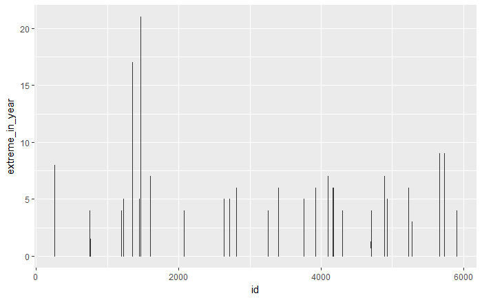

```r
#View(rain.annual)
library(lubridate)
library(dplyr)
library(tidyr)
library(ggplot2)
dttm= ymd(rain.annual$date)
rain.annual %>%
ggplot(mapping = aes(x=id, y=extreme_in_year))+
  geom_violin(aes(group=id))
```

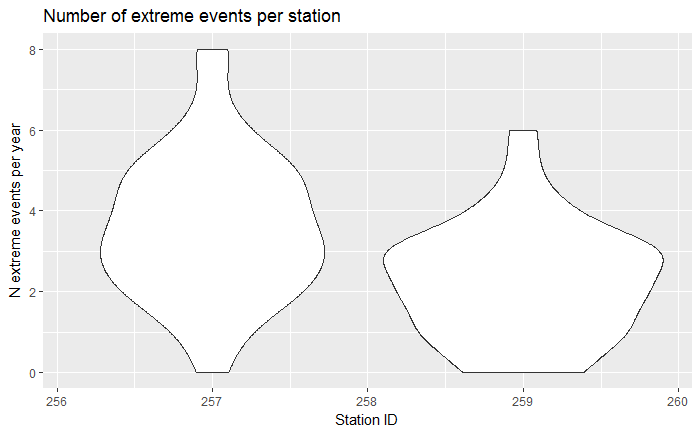

```r
rain.annual %>% filter(id >= 250 & id < 300) %>%
ggplot(mapping = aes(x=id, y=extreme_in_year))+
  geom_violin(aes(group=id)) +
  ggtitle("Number of extreme events per station") + # add a title
  ylab("N extreme events per year") + # add a y-axis label
  xlab("Station ID")  # add a x-axis label
```

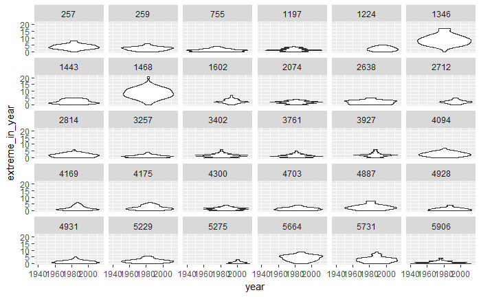

```r
rain.annual %>%
ggplot(mapping = aes(x=year, y=extreme_in_year))+
  geom_violin()+facet_wrap(~id)
```

```r
NA
```

Redo the last exercise for the monthly extreme rainfall counts. Does this change the picture?

```sql
select * from elisa_precipitation_month order by month asc
```

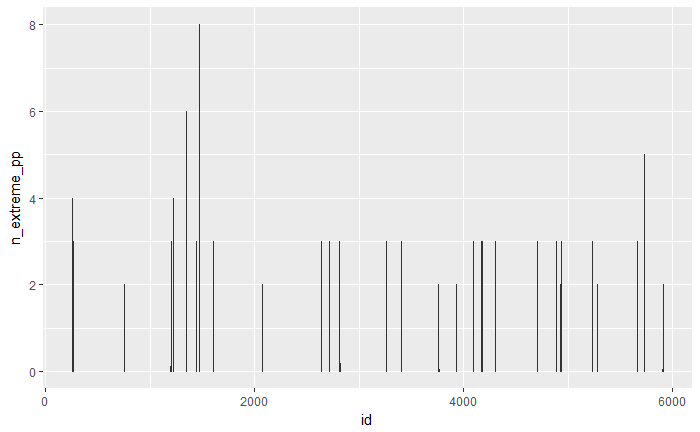

```r
#View(rain.monthly)
rain.monthly %>%
ggplot(mapping = aes(x=id, y=n_extreme_pp))+
  geom_violin(aes(group=id))
```

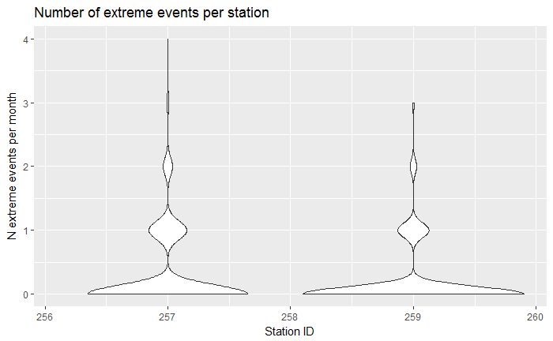

```r
rain.monthly %>% filter(id >= 250 & id < 260) %>%
ggplot(mapping = aes(x=id, y=n_extreme_pp))+
  geom_violin(aes(group=id)) +
  ggtitle("Number of extreme events per station") + # add a title
  ylab("N extreme events per month") + # add a y-axis label
  xlab("Station ID")  # add a x-axis label
```

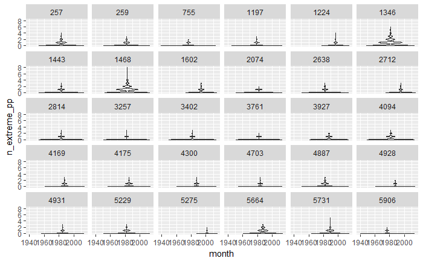

```r
rain.monthly %>%
ggplot(mapping = aes(x=month, y=n_extreme_pp))+
  geom_violin()+facet_wrap(~id)
```

What can you say about the distribution of extreme rainfall events from these plots? Answer: The plot shows that usually, most months do not have extreme events while the most frequent number of extreme events per month is just one event. This is reasonable since extreme events are “extreme” and therefor not usual. However, at least in these two stations showed, the most frequent number of extreme events during one year are 2 to 4 events.

Load the locations for the used stations from the database.

Plot these locations and represent any measure for annual variance in extreme rainfall events by the point size of the used locations.

```sql
select s.id, name, st_x(st_transform(geometry, 4326)) as lon, st_y(st_transform(geometry, 4326)) as lat, min(e.extreme_in_year)as min, max(e.extreme_in_year) as max, stddev(e.extreme_in_year) as st_dev from stations s
join elisa_precipitation_year e
on s.id=e.id
group by s.id
```

| id | name | lon | lat | min | max | st_dev |
| --- | --- | --- | --- | --- | --- | --- |
| 257 | Baden_Baden_Geroldsau | 8.2458 | 48.7270 | 0 | 8 | 1.7790607 |
| 259 | Muellheim | 7.6387 | 47.8064 | 0 | 6 | 1.4259602 |
| 755 | Buchen_Kr_Neckar_Odenwald | 9.3213 | 49.5182 | 0 | 4 | 1.0744442 |
| 1197 | Ellwangen_Rindelbach | 10.1312 | 48.9895 | 0 | 4 | 1.0155547 |
| 1224 | Emmendingen_Mundingen | 7.8351 | 48.1378 | 0 | 5 | 1.3878936 |
| 1346 | Feldberg_Schwarzwald | 8.0038 | 47.8749 | 0 | 17 | 3.7515777 |
| 1443 | Freiburg | 7.8344 | 48.0233 | 0 | 5 | 1.5052586 |
| 1468 | Freudenstadt | 8.4091 | 48.4537 | 0 | 21 | 3.8358264 |
| 1602 | Ohlsbach | 7.9931 | 48.4329 | 0 | 7 | 1.5324192 |
| 2074 | Hechingen | 8.9801 | 48.3751 | 0 | 4 | 1.0730078 |

[output cut: 20 more lines]

```sql
select s.id, name, st_x(st_transform(geometry, 4326)) as lon, st_y(st_transform(geometry, 4326)) as lat, min(e.extreme_in_year)as min, max(e.extreme_in_year) as max, stddev(e.extreme_in_year) as st_dev from stations s
join elisa_precipitation_year e
on s.id=e.id
group by s.id
```

Plot these locations and represent any measure for annual variance in extreme rainfall events by the point size of the used locations.

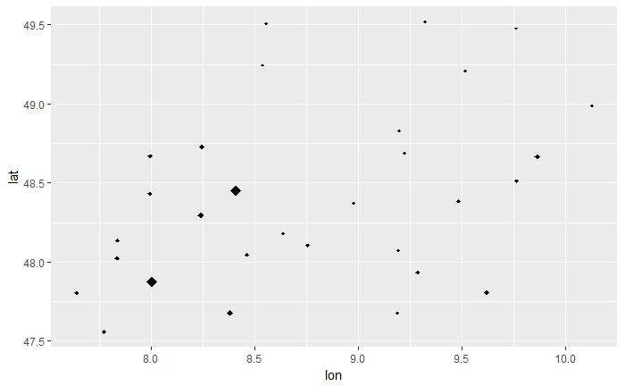

```r
#View(locations)
ggplot(locations, aes(x=lon, y=lat)) + geom_point(shape=18, size=locations$st_dev)
```

**OPTIONAL:** Additionally mark the station showing the most and least recorded extreme rainfalls by another marker into the same plot. (eg. use a green and a red cross or star.)

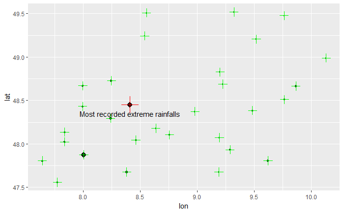

```r
library(dplyr)
library(tidyr)
max_station<-locations %>% filter(max==max(max))
min_station<-locations %>% filter(min==0)
ggplot(locations, aes(x=lon, y=lat)) + geom_point(shape=18, size=locations$st_dev)+
  geom_point(data=min_station, aes(x=lon, y=lat), colour="green", shape=3, size=4)+
  geom_point(data=max_station, aes(x=lon, y=lat), colour="red", shape=3, size=8)+
  scale_colour_manual("",
          breaks = c("Most","Less"),
          values = c("red","green"))+
  geom_text(data=max_station, label="Most recorded extreme rainfalls", vjust=2)+
  theme(legend.position = "right")
```

How can you interpret this result?